# sources – EU Omnibus Briefing

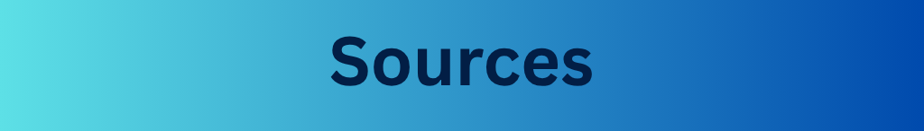

Accountancy Europe. (2025). Omnibus explained: key changes to CSDDD - Accountancy Europe. [online] Available at: https://accountancyeurope.eu/publications/omnibus-explained-key-changes-to-csddd/ [Accessed 19 Jun. 2025].

Clifford Chance. (2025). The EU Corporate Sustainability Due Diligence Directive – Which companies are in scope and when will they have to comply? [online] Available at: https://www.cliffordchance.com/insights/resources/blogs/business-and-human-rights-insights/2025/01/the-eu-corporate-sustainability-due-diligence-directive.html [Accessed 3 Jun. 2025].

EU Omnibus: What’s next for the sustainability simplification push?, (2025). The Responsible Investor Podcast. 31 Mar.

eur-lex.europa.eu. (n.d.). EUR-Lex - SME - EN - EUR-Lex. [online] Available at: https://eur-lex.europa.eu/EN/legal-content/glossary/small-and-medium-sized-enterprises.html [Accessed 3 Jun. 2025].

Europa.eu. (2025). Directive - EU - 2025/794 - EN - EUR-Lex. [online] Available at: https://eur-lex.europa.eu/legal-content/en/TXT/?uri=CELEX%3A32025L0794 [Accessed 3 Jun. 2025].

European Energy Exchange AG (EEX) (2024) EEX EUA Primary Auction Spot Data. Available at: https://www.eex.com/en/market-data/market-data-hub/environmentals/eex-eua-primary-auction-spot-download (Accessed: 25 June 2025).

Exchange-rates.org. (2024). GBP to EUR Exchange Rate History for 2024. [online] Available at: https://www.exchange-rates.org/exchange-rate-history/gbp-eur-2024 [Accessed 25 Jun. 2025].

Ey.com. (2025). EU’s Omnibus Proposal: Key changes to the CSRD, CS3D and Taxonomy. [online] Available at: https://www.ey.com/en_be/technical/tax/tax-alerts/2025/eus-omnibus-proposal-key-changes-to-the-csrd-cs3d-and-taxonomy [Accessed 16 Jun. 2025].

Guidance Document The Monitoring and Reporting Regulation - General guidance for installations. (2025). Available at: https://climate.ec.europa.eu/document/download/d4f11230-9126-41a8-8c42-6131cd4e742e_en?filename=gd1_guidance_installations_en.pdf [Accessed 17 Jun. 2025].

IRS (2024). Yearly Average Currency Exchange Rates | Internal Revenue Service. [online] Irs.gov. Available at: https://www.irs.gov/individuals/international-taxpayers/yearly-average-currency-exchange-rates [Accessed 11 Jun. 2025].

Jones, S. (2025). Mastering EU Taxonomy Reporting: A Step-by-Step Guide to Compliance and Beyond. [online] Lythouse. Available at: https://www.lythouse.com/blog/mastering-eu-taxonomy-reporting-a-step-by-step-guide-to-compliance-and-beyond [Accessed 26 Jun. 2025].

Navigating the EU Omnibus, (2025). [Podcast] Sustainable Connections. 10 Apr.

Sidley.com. (2025). EU Omnibus Package: Key Changes Proposed by the Commission on the Carbon Border Adjustment Mechanism. [online] Available at: https://www.sidley.com/en/insights/newsupdates/2025/03/eu-omnibus-package-key-changes-proposed-by-the-commission-on-the-carbon-border-adjustment-mechanism [Accessed 10 Jun. 2025].

Report prepared by Claire Bassett, July 2025